# alonso

GRUPO 9

2025-03-27

## 0.1 Cargar los datos

```r
library(readr)
library(ggplot2)
dataset_Facebook <- read_delim("~/Escritorio/2carrera/segundo_cuatri/modelos_regresion/facebook+metrics/dataset_Facebook.csv",
    delim = ";", escape_double = FALSE, trim_ws = TRUE)
# lectura de datos en csv
#datos<-read.csv("dataset_Facebook.csv")
# Cambiamos el nombre de las variables

#datos<-read.csv("datos/datos.csv")
ntotal <- dim(dataset_Facebook)[1] # numero de observaciones
ptotal <- dim(dataset_Facebook)[2] # numero de columnas
```

## 0.2 Partición de los datos

Realizamos la división de nuestros datos en 3 muestras: entrenamiento, validación y test.

```r
# mediante una semilla conseguimos que el ejercicio sea reproducible
set.seed(1)


# creamos índices
indices <- 1:ntotal
ntrain <- ntotal * .5
ntest <- ntotal * .25
nval <- ntotal - (ntrain+ntest)
indices.train <- sample(indices, ntrain, replace = FALSE)
indices.test <- sample(indices[-indices.train],ntest,replace=FALSE)
indices.val <- indices[-c(indices.train,indices.test)]

# Usamos el 50% de la base de datos como conjunto de entrenamiento
# 25% para test
# 25% para validación
train  <- dataset_Facebook[indices.train, ]
test   <- dataset_Facebook[indices.test, ]
val   <- dataset_Facebook[indices.val, ]
```

```r
# Cargar librerías necesarias
library(knitr)

# Crear un data frame con las descripciones de las variables
tabla_variables <- data.frame(
  Variable = c("Page total likes", "Type", "Category", "Post Month", "Post Weekday",
               "Post Hour", "Paid", "Lifetime Post Total Reach", "Lifetime Post Total Impressions",
               "Lifetime Engaged Users", "Lifetime Post Consumers", "Lifetime Post Consumptions",
               "Lifetime Post Impressions by people who have liked your Page",
               "Lifetime Post reach by people who like your Page",
               "Lifetime People who have liked your Page and engaged with your post",
               "comment", "like", "share", "Total Interactions"),

  Tipo = c("Numérica", "Categórica", "Categórica", "Numérica", "Numérica",
           "Numérica", "Binaria", "Numérica", "Numérica",
           "Numérica", "Numérica", "Numérica",
           "Numérica", "Numérica",
           "Numérica", "Numérica", "Numérica", "Numérica", "Numérica"),

  Descripción = c("Cantidad total de 'me gusta' en la página",
                  "Tipo de post (foto, estado, video, etc.)",
                  "Categoría del post",
                  "Mes en el que se realizó la publicación",
                  "Día de la semana en que se publicó",
                  "Hora del día en que se publicó",
                  "Indica si la publicación fue pagada (1) o no (0)",
                  "Alcance total de la publicación",
                  "Total de impresiones de la publicación",
                  "Usuarios comprometidos con la publicación",
                  "Número de consumidores de la publicación",
                  "Total de interacciones con la publicación",
                  "Impresiones por personas que han dado 'me gusta' a la página",
                  "Alcance de la publicación por personas que han dado 'me gusta' a la página",
                  "Personas que dieron 'me gusta' a la página e interactuaron con la publicación",
                  "Número de comentarios en la publicación",
                  "Número de 'me gusta' en la publicación",
                  "Número de veces que se compartió la publicación",
                  "Total de interacciones (comentarios, likes y compartidos)")
)

# Mostrar la tabla en formato bonito
kable(tabla_variables, caption = "Descripción de las Variables del Dataset")
```

Descripción de las Variables del Dataset

| Variable | Tipo | Descripción |
| --- | --- | --- |
| Page total likes | Numérica | Cantidad total de ‘me gusta’ en la página |
| Type | Categórica | Tipo de post (foto, estado, video, etc.) |
| Category | Categórica | Categoría del post |
| Post Month | Numérica | Mes en el que se realizó la publicación |
| Post Weekday | Numérica | Día de la semana en que se publicó |
| Post Hour | Numérica | Hora del día en que se publicó |
| Paid | Binaria | Indica si la publicación fue pagada (1) o no (0) |
| Lifetime Post Total Reach | Numérica | Alcance total de la publicación |
| Lifetime Post Total Impressions | Numérica | Total de impresiones de la publicación |
| Lifetime Engaged Users | Numérica | Usuarios comprometidos con la publicación |
| Lifetime Post Consumers | Numérica | Número de consumidores de la publicación |
| Lifetime Post Consumptions | Numérica | Total de interacciones con la publicación |
| Lifetime Post Impressions by people who have liked your Page | Numérica | Impresiones por personas que han dado ‘me gusta’ a la página |
| Lifetime Post reach by people who like your Page | Numérica | Alcance de la publicación por personas que han dado ‘me gusta’ a la página |
| Lifetime People who have liked your Page and engaged with your post | Numérica | Personas que dieron ‘me gusta’ a la página e interactuaron con la publicación |
| comment | Numérica | Número de comentarios en la publicación |
| like | Numérica | Número de ‘me gusta’ en la publicación |
| share | Numérica | Número de veces que se compartió la publicación |
| Total Interactions | Numérica | Total de interacciones (comentarios, likes y compartidos) |

## 0.3 Tamaño de la base de datos

```r
dim(dataset_Facebook)
```

```
## [1] 500  19
```

Hay **500** observaciones y **19** variables **Todas** nuestras **variables** son **discretas**.

# 1 Calculos estadísticos

# 2 Page total likes

```r
# Media page total likes

mean(dataset_Facebook$`Page total likes`)
```

```
## [1] 123194.2
```

```r
# desviacion tipica

sd(dataset_Facebook$`Page total likes`)
```

```
## [1] 16272.81
```

```r
#frecuencia
# frecuencia absoluta
ptlikes <- (dataset_Facebook$`Page total likes`)
table(ptlikes)
```

```
## ptlikes
##  81370  85093  85979  86491  86909  91009  91116  91223  91330  91437  91544
##      4      3      7      5      6      1      1      1      1      1      1
##  91651  91758  91865  91972  92079  92186  92293  92400  92507  92614  92721
##      1      1      1      1      1      1      1      1      1      1      1
##  92828  92935  93042  93149  93256  93363  93470  93577  93684  96749  98195
##      1      1      1      1      1      1      1      1      1      6      5
## 100732 102112 104070 106928 107907 109670 111620 113028 115368 115893 116091
##     12      8      5      6     13     13      6      6      4      2      6
## 116435 117764 119198 120050 121540 123047 124940 125612 126141 126345 126424
##      7     11      8      4      2      9     17     10      6      5      5
## 127082 128032 129600 130791 131300 131630 131728 131808 131956 132201 132817
##      1     10     15      8      4      6      3      4      7     10      6
## 133451 133594 133679 134879 135195 135428 135617 135700 135713 136013 136393
##      1      5      4      9     10      6      5      4      8     10     18
## 136642 136736 137020 137059 137177 137893 138185 138329 138353 138414 138458
##      6      6      9      9     12      8      9      9      9     11      3
## 138895 139441
##     14     14
```

```r
#frecuencia relativa
prop.table(ptlikes)
```

[output not shown]

[output cut: 69 more lines]

# 3 Type

```r
#tabla frecuencias

table(dataset_Facebook$Type)
```

```
##
##   Link  Photo Status  Video
##     22    426     45      7
```

```r
prop.table(table(dataset_Facebook$Type))
```

```
##
##   Link  Photo Status  Video
##  0.044  0.852  0.090  0.014
```

```r
summary(train
        )
```

```
##  Page total likes     Type              Category       Post Month
##  Min.   : 81370   Length:250         Min.   :1.000   Min.   : 1.000
##  1st Qu.:110158   Class :character   1st Qu.:1.000   1st Qu.: 4.000
##  Median :128032   Mode  :character   Median :2.000   Median : 7.000
##  Mean   :122570                      Mean   :1.888   Mean   : 6.936
##  3rd Qu.:136393                      3rd Qu.:3.000   3rd Qu.:10.000
##  Max.   :139441                      Max.   :3.000   Max.   :12.000
##
##   Post Weekday     Post Hour           Paid        Lifetime Post Total Reach
##  Min.   :1.000   Min.   : 1.000   Min.   :0.0000   Min.   :   238
##  1st Qu.:2.000   1st Qu.: 3.000   1st Qu.:0.0000   1st Qu.:  3060
##  Median :4.000   Median : 9.000   Median :0.0000   Median :  4925
##  Mean   :4.028   Mean   : 7.836   Mean   :0.2329   Mean   : 13316
##  3rd Qu.:6.000   3rd Qu.:11.000   3rd Qu.:0.0000   3rd Qu.: 11577
##  Max.   :7.000   Max.   :23.000   Max.   :1.0000   Max.   :139008
##                                   NA's   :1
##  Lifetime Post Total Impressions Lifetime Engaged Users Lifetime Post Consumers
##  Min.   :   570                  Min.   :  15.0         Min.   :  15.0
##  1st Qu.:  5419                  1st Qu.: 365.8         1st Qu.: 322.0
##  Median :  8379                  Median : 580.5         Median : 523.5
##  Mean   : 26904                  Mean   : 843.2         Mean   : 738.0
##  3rd Qu.: 20366                  3rd Qu.:1040.2         3rd Qu.: 936.2
##  Max.   :665792                  Max.   :6164.0         Max.   :5934.0
##
##  Lifetime Post Consumptions
##  Min.   :   19.0
##  1st Qu.:  477.5
##  Median :  788.0
##  Mean   : 1356.0
##  3rd Qu.: 1421.2
##  Max.   :19779.0
##
##  Lifetime Post Impressions by people who have liked your Page
##  Min.   :   567
##  1st Qu.:  3807
##  Median :  6059
##  Mean   : 14896
##  3rd Qu.: 13862
##  Max.   :648611
##
```

[output cut: 9 more lines]

```
##  Min.   :  15.0
##  1st Qu.: 270.0
##  Median : 389.0
##  Mean   : 567.4
##  3rd Qu.: 643.2
##  Max.   :4376.0
##
##     comment             like            share        Total Interactions
##  Min.   :  0.000   Min.   :   0.0   Min.   :  0.00   Min.   :   0.00
##  1st Qu.:  1.000   1st Qu.:  53.0   1st Qu.:  9.00   1st Qu.:  66.25
##  Median :  3.000   Median :  96.5   Median : 18.00   Median : 117.00
##  Mean   :  6.732   Mean   : 156.2   Mean   : 23.78   Mean   : 186.56
##  3rd Qu.:  6.750   3rd Qu.: 184.8   3rd Qu.: 31.00   3rd Qu.: 221.00
##  Max.   :146.000   Max.   :1546.0   Max.   :181.00   Max.   :1873.00
##                                     NA's   :2
```

# 4 Category

```r
#tabla freceuncias

table(dataset_Facebook$Category)
```

```
##
##   1   2   3
## 215 130 155
```

```r
prop.table(table(dataset_Facebook$Category))
```

```
##
##    1    2    3
## 0.43 0.26 0.31
```

# 5 Post month

```r
# tabla frecuencias
table(dataset_Facebook$`Post Month`)
```

```
##
##  1  2  3  4  5  6  7  8  9 10 11 12
## 25 26 36 50 37 49 52 34 36 60 45 50
```

```r
prop.table(table(dataset_Facebook$`Post Month`))
```

```
##
##     1     2     3     4     5     6     7     8     9    10    11    12
## 0.050 0.052 0.072 0.100 0.074 0.098 0.104 0.068 0.072 0.120 0.090 0.100
```

# 6 Post Weekday

```r
# frecuencias
table(dataset_Facebook$`Post Weekday`)
```

```
##
##  1  2  3  4  5  6  7
## 68 66 64 72 67 81 82
```

```r
prop.table(table(dataset_Facebook$`Post Weekday`))
```

```
##
##     1     2     3     4     5     6     7
## 0.136 0.132 0.128 0.144 0.134 0.162 0.164
```

# 7 Post hour

```r
# frecuencias
table(dataset_Facebook$`Post Hour`)
```

```
##
##   1   2   3   4   5   6   7   8   9  10  11  12  13  14  15  16  17  18  19  20
##   4  39 105  35  13  16  13  12  30  78  44  29  52  13   6   1   3   3   1   1
##  22  23
##   1   1
```

```r
prop.table(table(dataset_Facebook$`Post Hour`))
```

```
##
##     1     2     3     4     5     6     7     8     9    10    11    12    13
## 0.008 0.078 0.210 0.070 0.026 0.032 0.026 0.024 0.060 0.156 0.088 0.058 0.104
##    14    15    16    17    18    19    20    22    23
## 0.026 0.012 0.002 0.006 0.006 0.002 0.002 0.002 0.002
```

# 8 Paid

```r
# frecuencias
table(dataset_Facebook$Paid)
```

```
##
##   0   1
## 360 139
```

```r
prop.table(table(dataset_Facebook$Paid))
```

```
##
##         0         1
## 0.7214429 0.2785571
```

# 9 Life time post total reach

```r
# media
mean(dataset_Facebook$`Lifetime Post Total Reach`)
```

```
## [1] 13903.36
```

```r
# desviacion tipica
sd(dataset_Facebook$`Lifetime Post Total Reach`)
```

```
## [1] 22740.79
```

```r
summary(train$`Page total likes`
        )
```

```
##    Min. 1st Qu.  Median    Mean 3rd Qu.    Max.
##   81370  110158  128032  122570  136393  139441
```

# 10 Enfrentar variable con el target

```r
#LIKE
cor(train$`Total Interactions`, train$like, use="complete.obs")  # Correlación
```

```
## [1] 0.9960257
```

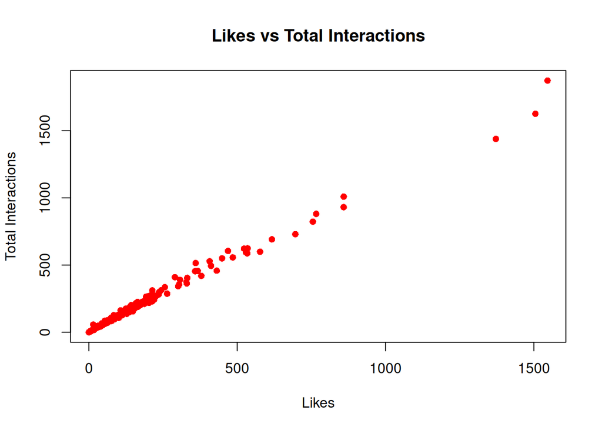

```r
plot(train$like, train$`Total Interactions`, main="Likes vs Total Interactions",
     xlab="Likes", ylab="Total Interactions", col="red", pch=16)
```

```r
#COMMENT
cor(train$`Total Interactions`, train$comment, use="complete.obs")  # Correlación
```

```
## [1] 0.6445437
```

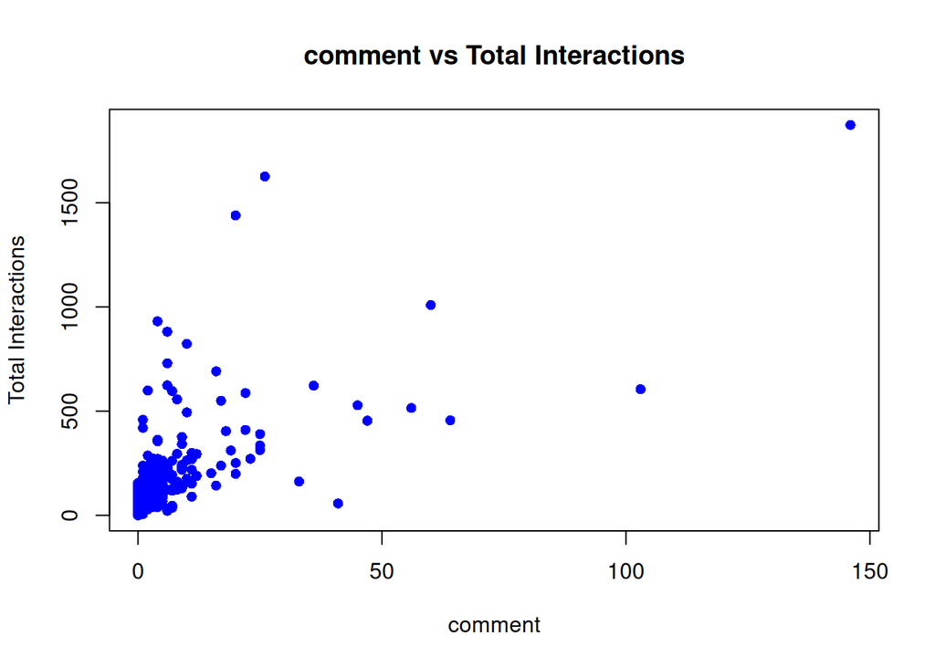

```r
plot(train$comment, train$`Total Interactions`, main="comment vs Total Interactions",
     xlab="comment", ylab="Total Interactions", col="blue", pch=16)
```

```r
#SHARE
cor(train$`Total Interactions`, train$share, use="complete.obs")  # Correlación
```

```
## [1] 0.8169935
```

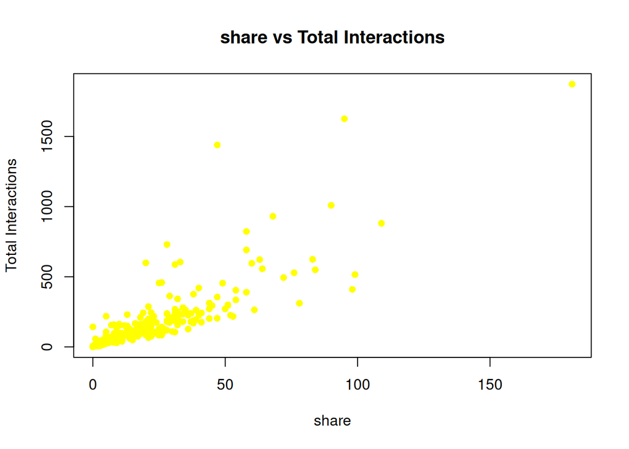

```r
plot(train$share, train$`Total Interactions`, main="share vs Total Interactions",
     xlab="share", ylab="Total Interactions", col="yellow", pch=16)
```

```r
#Lifetime People who have liked your Page and engaged with your post

cor(train$`Total Interactions`, train$`Lifetime People who have liked your Page and engaged with your post`, use="complete.obs")  # Correlación
```

```
## [1] 0.5987753
```

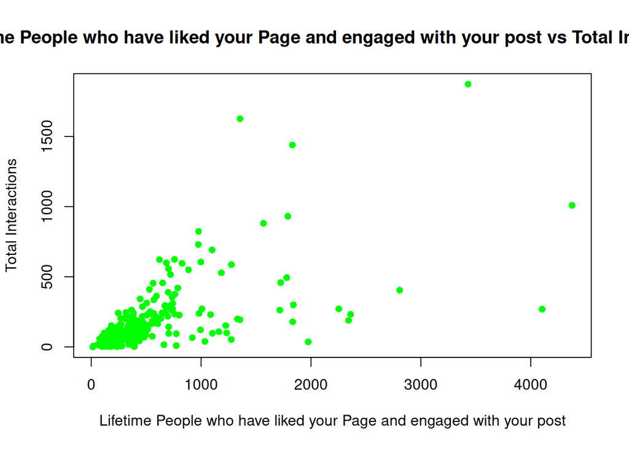

```r
plot(train$`Lifetime People who have liked your Page and engaged with your post`, train$`Total Interactions`, main="Lifetime People who have liked your Page and engaged with your post vs Total Interactions",
     xlab="Lifetime People who have liked your Page and engaged with your post", ylab="Total Interactions", col="green", pch=16)
```

```r
#Lifetime Post reach by people who like your Page

cor(train$`Total Interactions`, train$`Lifetime Post reach by people who like your Page`, use="complete.obs")  # Correlación
```

```
## [1] 0.6961768
```

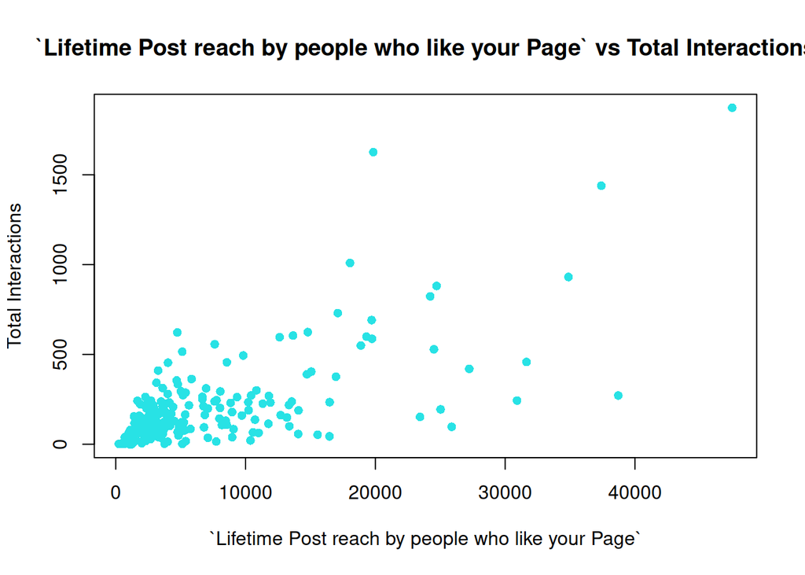

```r
plot(train$`Lifetime Post reach by people who like your Page`, train$`Total Interactions`, main="`Lifetime Post reach by people who like your Page` vs Total Interactions",
     xlab="`Lifetime Post reach by people who like your Page`", ylab="Total Interactions", col="4157", pch=16)
```

```r
#Lifetime Post Impressions by people who have liked your Page


cor(train$`Total Interactions`, train$`Lifetime Post Impressions by people who have liked your Page`, use="complete.obs")  # Correlación
```

```
## [1] 0.5984853
```

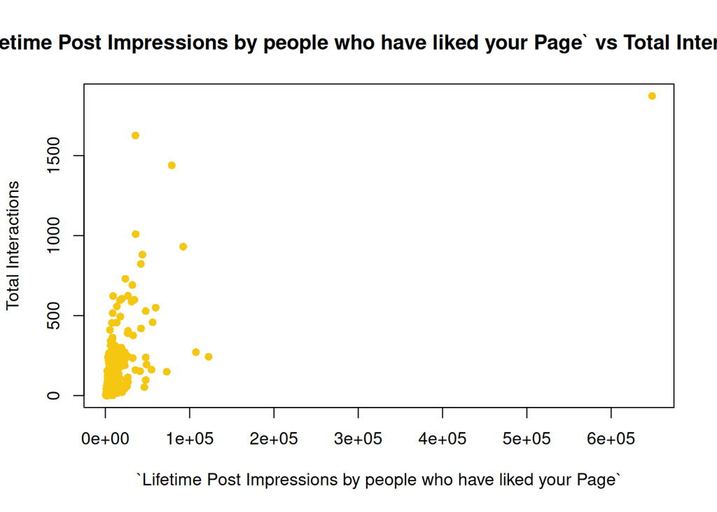

```r
plot(train$`Lifetime Post Impressions by people who have liked your Page`, train$`Total Interactions`, main="`Lifetime Post Impressions by people who have liked your Page` vs Total Interactions",
     xlab="`Lifetime Post Impressions by people who have liked your Page`", ylab="Total Interactions", col="5423", pch=16)
```

# 11 Modelo lineal simple LIKE , TOTAL INTERACTIONS

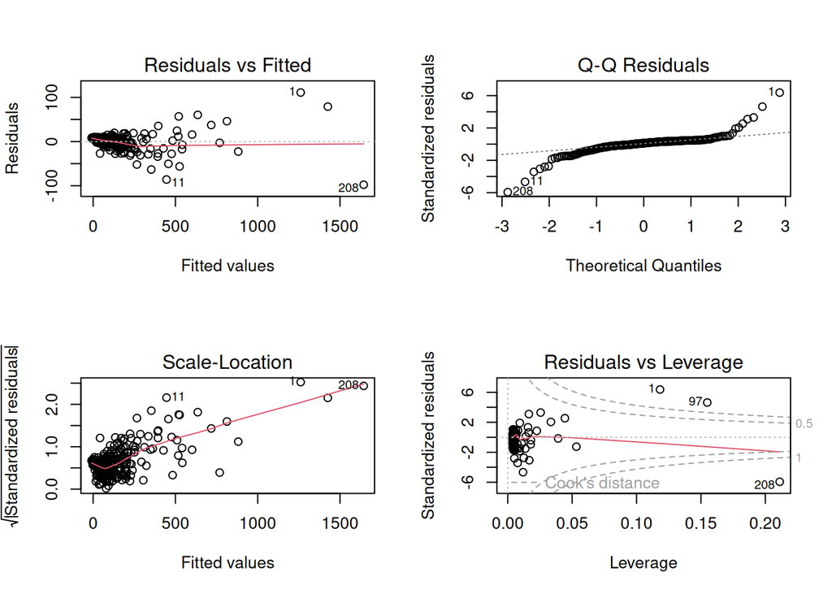

```r
# Ajustar el modelo de regresión lineal
modelo <- lm(train$like ~ train$`Total Interactions`)
par(mfrow = c(2,2))
plot(modelo)
```

```r
# Obtener estimadores de los parámetros y errores estándar
estimadores <- coef(summary(modelo))  # Incluye estimadores y errores estándar

# Imprimir los resultados
cat("Estimadores para los parámetros del modelo:\n")
```

```
## Estimadores para los parámetros del modelo:
```

```r
print(estimadores)
```

```
##                              Estimate  Std. Error    t value      Pr(>|t|)
## (Intercept)                -8.3188003 1.500325260  -5.544665  7.527012e-08
## train$`Total Interactions`  0.8820665 0.005008633 176.109248 1.718373e-262
```

```r
summary(modelo)
```

```
##
## Call:
## lm(formula = train$like ~ train$`Total Interactions`)
##
## Residuals:
##     Min      1Q  Median      3Q     Max
## -97.792  -4.331   2.160   6.907 111.025
##
## Coefficients:
##                             Estimate Std. Error t value Pr(>|t|)
## (Intercept)                -8.318800   1.500325  -5.545 7.53e-08 ***
## train$`Total Interactions`  0.882067   0.005009 176.109  < 2e-16 ***
## ---
## Signif. codes:  0 '***' 0.001 '**' 0.01 '*' 0.05 '.' 0.1 ' ' 1
##
## Residual standard error: 18.56 on 248 degrees of freedom
## Multiple R-squared:  0.9921, Adjusted R-squared:  0.992
## F-statistic: 3.101e+04 on 1 and 248 DF,  p-value: < 2.2e-16
```

```r
# Obtener y mostrar la tabla ANOVA
tabla_anova <- anova(modelo)
cat("Tabla ANOVA:\n")
```

```
## Tabla ANOVA:
```

```r
#Tabla ANOVA:

print(tabla_anova)
```

```
## Analysis of Variance Table
##
## Response: train$like
##                             Df   Sum Sq  Mean Sq F value    Pr(>F)
## train$`Total Interactions`   1 10683634 10683634   31014 < 2.2e-16 ***
## Residuals                  248    85429      344
## ---
## Signif. codes:  0 '***' 0.001 '**' 0.01 '*' 0.05 '.' 0.1 ' ' 1
```

[figure not shown]

```r
# Cargar librerías necesarias
library(ggplot2)

# Crear el gráfico de dispersión con la línea de regresión
ggplot(train, aes(x = train$`Total Interactions`, y = train$`Lifetime Post Total Impressions`)) +
  geom_point(color = "blue", alpha = 0.6) +  # Puntos de datos reales
  geom_smooth(method = "lm", color = "red") +  # Línea de regresión basada en el modelo
  labs(title = "Relación entre Total Interactions y Likes",
       x = "Total Interactions",
       y = "Life time post total impressions") +
  theme_minimal()
```

# MODELOS NO LINEALES # Modelo polinomico

```r
# Ajuste del modelo polinómico de grado 2
#modelo_polinomico <- lm(train$like ~ poly(train$`Total Interactions`, 2), data = train)

# Resumen del modelo
#summary(modelo_polinomico)
#plot(modelo_polinomico)
# Visualización
#plot(x, y, main = "Regresión Polinómica de Segundo Grado", pch = 19, col = "blue")
#lines(x, predict(modelo_polinomico), col = "red", lwd = 2)
```

```r
# Cargar librerías necesarias
library(ggplot2)

# Ajuste del modelo polinómico de grado 2
modelo_polinomico <- lm(comment ~ poly(`Total Interactions`, 2), data = train)

# Resumen del modelo
summary(modelo_polinomico)
```

```
##
## Call:
## lm(formula = comment ~ poly(`Total Interactions`, 2), data = train)
##
## Residuals:
##     Min      1Q  Median      3Q     Max
## -45.178  -2.894  -1.209   1.080  82.259
##
## Coefficients:
##                                Estimate Std. Error t value Pr(>|t|)
## (Intercept)                      6.7320     0.6922   9.725   <2e-16 ***
## poly(`Total Interactions`, 2)1 146.2945    10.9450  13.366   <2e-16 ***
## poly(`Total Interactions`, 2)2  22.9401    10.9450   2.096   0.0371 *
## ---
## Signif. codes:  0 '***' 0.001 '**' 0.01 '*' 0.05 '.' 0.1 ' ' 1
##
## Residual standard error: 10.94 on 247 degrees of freedom
## Multiple R-squared:  0.4257, Adjusted R-squared:  0.421
## F-statistic: 91.53 on 2 and 247 DF,  p-value: < 2.2e-16
```

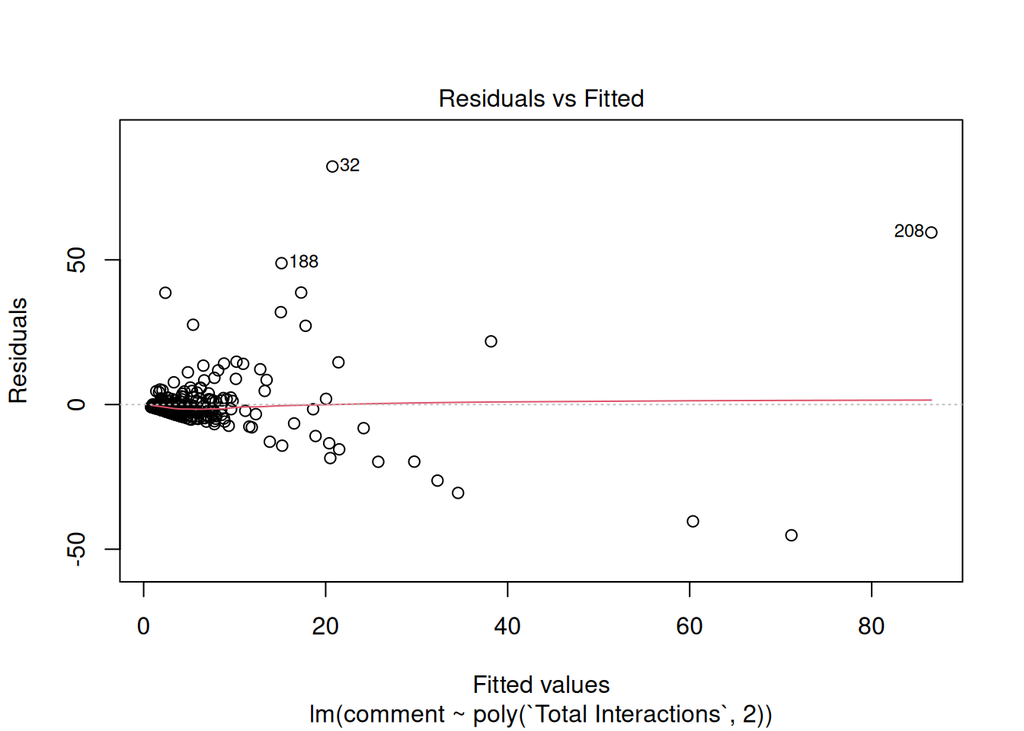

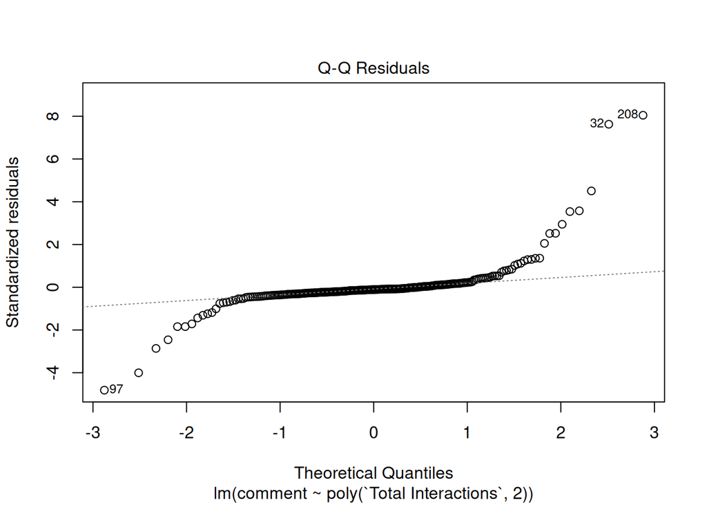

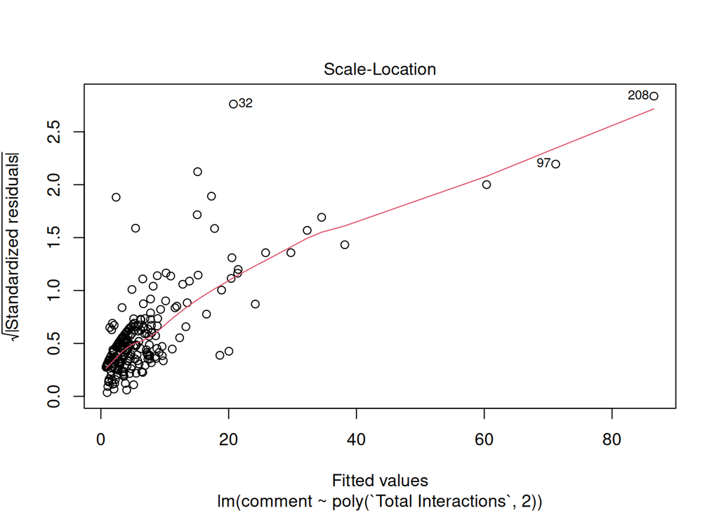

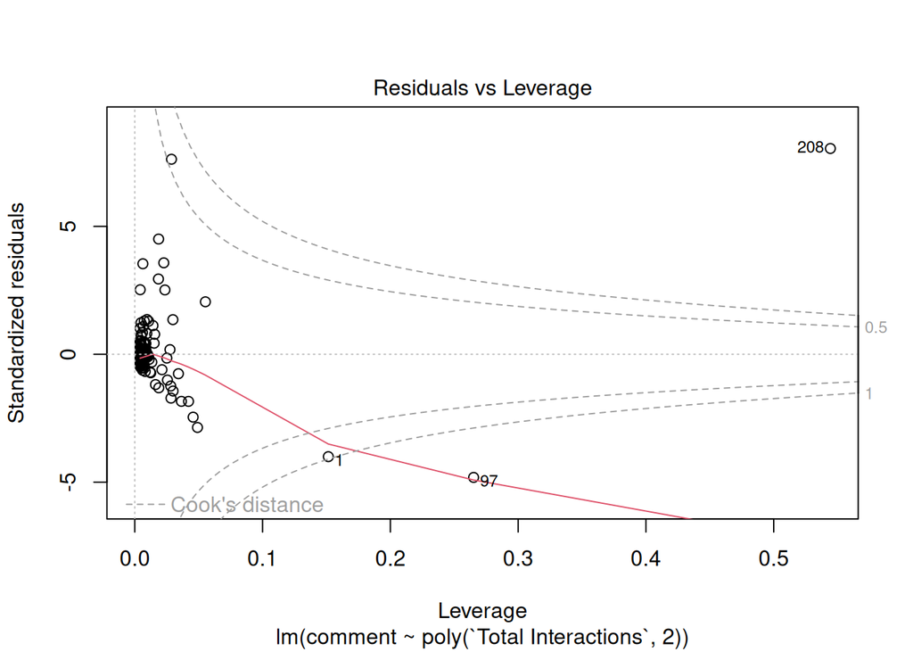

```r
# Diagnóstico del modelo
plot(modelo_polinomico)
```

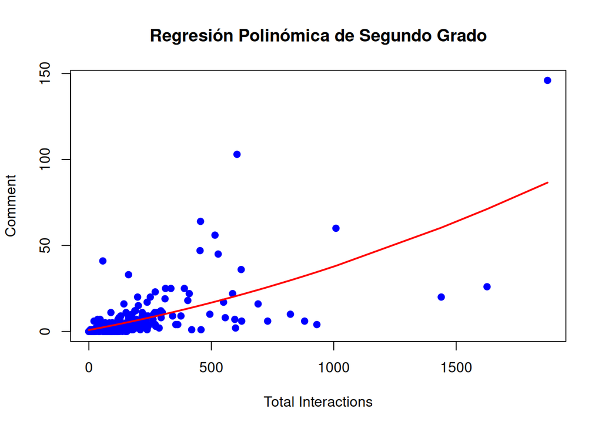

```r
# Visualización de la regresión polinómica
# Ordenamos los valores de X para que la curva de la predicción sea suave
x_ordenado <- train[order(train$`Total Interactions`), ]  # Ordenar datos
predicciones <- predict(modelo_polinomico, newdata = x_ordenado)  # Predicciones ordenadas

# Gráfico base con puntos
plot(train$`Total Interactions`, train$comment,
     main = "Regresión Polinómica de Segundo Grado",
     pch = 19, col = "blue", xlab = "Total Interactions", ylab = "Comment")

# Agregar la línea de la regresión
lines(x_ordenado$`Total Interactions`, predicciones, col = "red", lwd = 2)
```

# Modelos de Regresión Exponencial y Logarítmica

```r
# Asegurar que los valores de 'Total Interactions' sean positivos para aplicar logaritmo
train$`Total Interactions`[train$`Total Interactions` <= 0] <-
  min(train$`Total Interactions`[train$`Total Interactions` > 0]) * 0.5

# Ajuste del modelo exponencial (transformación logarítmica)
modelo_exponencial <- lm(log(`Total Interactions`) ~ like, data = train)

# Ver resumen del modelo
summary(modelo_exponencial)
```

```
##
## Call:
## lm(formula = log(`Total Interactions`) ~ like, data = train)
##
## Residuals:
##     Min      1Q  Median      3Q     Max
## -3.9954 -0.1242  0.2942  0.5806  0.8674
##
## Coefficients:
##              Estimate Std. Error t value Pr(>|t|)
## (Intercept) 3.9954085  0.0741331   53.90   <2e-16 ***
## like        0.0040982  0.0002854   14.36   <2e-16 ***
## ---
## Signif. codes:  0 '***' 0.001 '**' 0.01 '*' 0.05 '.' 0.1 ' ' 1
##
## Residual standard error: 0.9365 on 248 degrees of freedom
## Multiple R-squared:  0.454,  Adjusted R-squared:  0.4518
## F-statistic: 206.2 on 1 and 248 DF,  p-value: < 2.2e-16
```

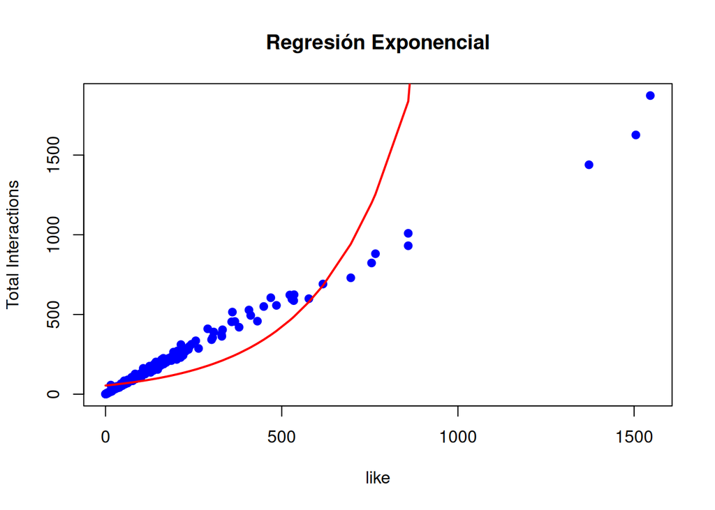

```r
# Visualización: relación entre like y Total Interactions
plot(train$like, train$`Total Interactions`,
     main = "Regresión Exponencial",
     pch = 19, col = "blue",
     ylab = "Total Interactions", xlab = "like")

# Predicciones para los valores reales de 'like'
predicciones <- predict(modelo_exponencial, newdata = train)

# Dibujar línea de predicción (transformación inversa de log)
orden <- order(train$like)
lines(train$like[orden], exp(predicciones[orden]), col = "red", lwd = 2)
```

# 12 Regresion spline

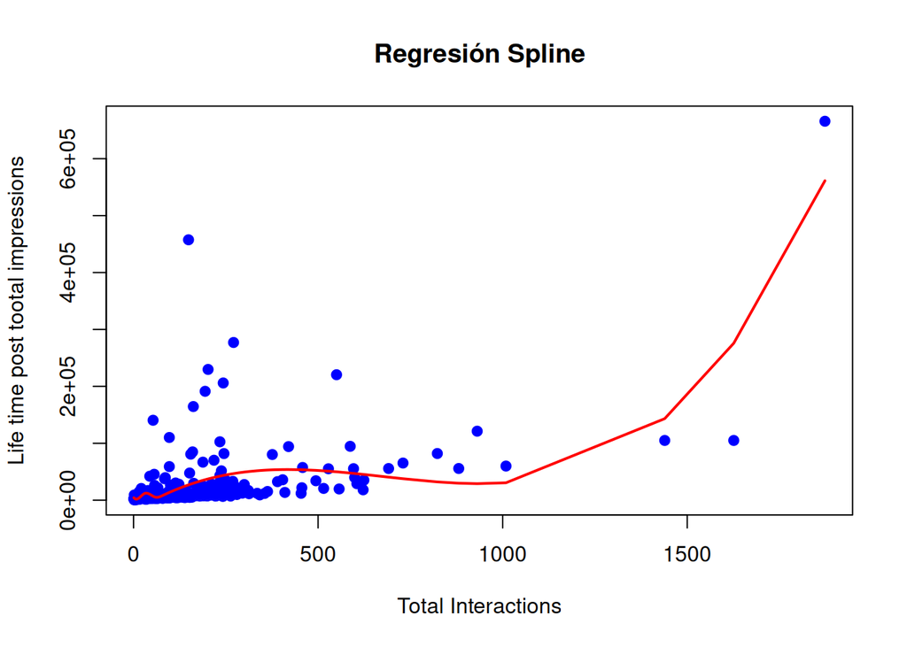

```r
# Cargar librería para splines
library(splines)

# Ajuste del modelo spline con tus datos reales
modelo_spline <- lm(train$`Lifetime Post Total Impressions` ~ bs(`Total Interactions`, knots = c(30, 60, 80)), data = train)

# Ordenar los datos por 'Total Interactions' para graficar correctamente
x_ordenado <- train[order(train$`Total Interactions`), ]

# Predicciones basadas en el modelo ajustado
predicciones <- predict(modelo_spline, newdata = x_ordenado)

# Gráfico de dispersión con la curva spline
plot(train$`Total Interactions`, train$`Lifetime Post Total Impressions`,
     main = "Regresión Spline",
     pch = 19, col = "blue",
     xlab = "Total Interactions", ylab = "Life time post tootal impressions")

# Agregar la línea de regresión spline
lines(x_ordenado$`Total Interactions`, predicciones, col = "red", lwd = 2)
```

# Transformación de variables

## 12.1 Transformación logaritmica

[figure not shown]

```r
# Modelo lineal con transformación logarítmica de la variable objetivo
modelo_log <- lm(log(train$`Total Interactions`) ~ like + comment + share, data = train)
# Visualización: relación entre 'like' y 'Total interactions'
plot(train$like, train$`Total interactions`,
     main = "Transformación logarítmica del modelo",
     pch = 19, col = "blue",
     ylab = "Total interactions", xlab = "like")
# Predicciones para los valores reales de 'like', 'comment' y 'share'
predicciones <- predict(modelo_log, newdata = train)

# Dibujar la curva ajustada (volviendo a escala original con exp)
orden <- order(train$like)  # para que la línea quede ordenada
lines(train$like[orden], exp(predicciones[orden]), col = "red", lwd = 2)
```

# Transformación de Raíz cuadrada

```r
# Ajuste del modelo con transformación raíz cuadrada en la variable dependiente
modelo_sqrt <- lm(sqrt(train$`Total Interactions`) ~ like, data = train)

# Ver resumen del modelo
summary(modelo_sqrt)
```

```
##
## Call:
## lm(formula = sqrt(train$`Total Interactions`) ~ like, data = train)
##
## Residuals:
##      Min       1Q   Median       3Q      Max
## -11.1491  -0.9165   0.4495   1.8465   4.7538
##
## Coefficients:
##              Estimate Std. Error t value Pr(>|t|)
## (Intercept) 7.3966973  0.1992715   37.12   <2e-16 ***
## like        0.0292864  0.0007671   38.18   <2e-16 ***
## ---
## Signif. codes:  0 '***' 0.001 '**' 0.01 '*' 0.05 '.' 0.1 ' ' 1
##
## Residual standard error: 2.517 on 248 degrees of freedom
## Multiple R-squared:  0.8546, Adjusted R-squared:  0.854
## F-statistic:  1458 on 1 and 248 DF,  p-value: < 2.2e-16
```

[figure not shown]

```r
# Visualización: datos reales
plot(train$like, train$`Total interactions`,
     main = "Transformación SQRT",
     pch = 19, col = "blue",
     ylab = "Total interactions", xlab = "like")
# Predicciones del modelo
predicciones <- predict(modelo_sqrt, newdata = train)

# Dibujar línea de predicción (transformando de nuevo al cuadrado)
orden <- order(train$like)
lines(train$like[orden], (predicciones[orden])^2, col = "red", lwd = 2)
```

```r
modelo_sqrt <- lm(sqrt(train$`Total Interactions`) ~ comment, data = train)
```

# 13 Transformación de Box-Cox

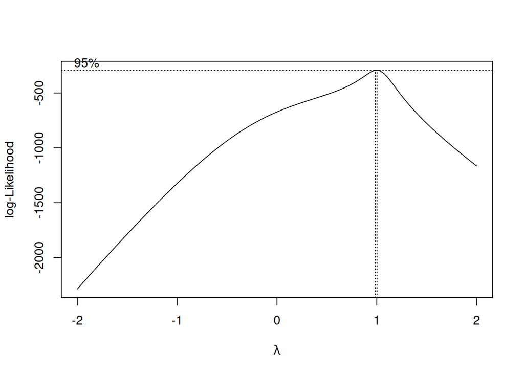

```r
# Cargar librería necesaria
library(MASS)

# Asegurar que 'Total Interactions' sea estrictamente positiva
if (min(train$`Total Interactions`) <= 0) {
  train$`Total Interactions` <- train$`Total Interactions` + abs(min(train$`Total Interactions`)) + 1
}

# Ajustar un modelo lineal simple
modelo_bc <- lm(`Total Interactions` ~ like, data = train)

# Aplicar transformación de Box-Cox
boxcox(modelo_bc,
       lambda = seq(-2, 2, 0.1),
       main = "Transformación de Box-Cox")
```

El valor óptimo de lambda ≈ 1 implica que no es necesario transformar la variable dependiente (Total Interactions), ya que: Lambda = 1 significa que el modelo lineal original con y sin transformar ya es adecuado. Otras transformaciones (como logarítmica, raíz cuadrada, inversa) no mejorarían significativamente el ajuste. Además, la curva del log-likelihood muestra un pico muy claro en λ = 1, y el intervalo de confianza del 95% (las líneas punteadas horizontales) incluye ese valor. Por lo tanto las tranformaciones anterioeres podemos decir que son innecesarias.

# 14 INGENIERÍA DE CARACTERÍSTICAS

## 14.1 Creación de una nueva variable. Variable de interacción

```r
# Crear nueva variable de interacción
train$like_share_interaccion <- train$like * train$share

# Ajustar modelo con interacción
modelo_interaccion <- lm(train$`Total Interactions` ~ like + share + like_share_interaccion, data = train)

# Ver resumen del modelo
summary(modelo_interaccion)
```

```
##
## Call:
## lm(formula = train$`Total Interactions` ~ like + share + like_share_interaccion,
##     data = train)
##
## Residuals:
##     Min      1Q  Median      3Q     Max
## -37.652  -3.375  -1.668   0.588  93.369
##
## Coefficients:
##                         Estimate Std. Error t value Pr(>|t|)
## (Intercept)            1.641e+00  1.149e+00   1.429    0.154
## like                   9.955e-01  6.452e-03 154.296  < 2e-16 ***
## share                  1.132e+00  4.957e-02  22.826  < 2e-16 ***
## like_share_interaccion 3.729e-04  6.046e-05   6.169 2.84e-09 ***
## ---
## Signif. codes:  0 '***' 0.001 '**' 0.01 '*' 0.05 '.' 0.1 ' ' 1
##
## Residual standard error: 10.39 on 244 degrees of freedom
##   (2 observations deleted due to missingness)
## Multiple R-squared:  0.9981, Adjusted R-squared:  0.998
## F-statistic: 4.211e+04 on 3 and 244 DF,  p-value: < 2.2e-16
```

Acerca del modelo de interacción: R² = 0.998 y R² ajustado = 0.998, lo que indica que el modelo explica el 99.8% de la variabilidad en Total Interactions. Error estándar residual ≈ 10.39, bastante bajo. p-valor global < 2.2e-16, lo que indica que el modelo es muy significativo. Like y share son altamente significativos (p < 2e-16) y contribuyen de forma positiva al número total de interacciones. La interacción like_share_interaccion también es significativa (p ≈ 2.84e-09), lo que quiere decir que el efecto de los “likes” en Total Interactions varía según el número de “shares” (y viceversa). Otra observacion que podemos ver es que el intercept no es significativo (p = 0.154), pero eso no afecta la utilidad predictiva si el resto del modelo es sólido.

# 15 Selección y reduccion de variables

```r
# Cargar librería
library(MASS)
train_limpio <- na.omit(train)
# Crear modelo completo con todas las variables numéricas
modelo_completo <- lm(`Total Interactions` ~
  `Page total likes` + Category + `Post Month` + `Post Weekday` + `Post Hour` + Paid +
  `Lifetime Post Total Reach` + `Lifetime Post Total Impressions` +
  `Lifetime Engaged Users` + `Lifetime Post Consumers` + `Lifetime Post Consumptions` +
  `Lifetime Post Impressions by people who have liked your Page` +
  `Lifetime Post reach by people who like your Page` +
  `Lifetime People who have liked your Page and engaged with your post` +
  comment + like + share + like_share_interaccion,
  data = train_limpio)

# Aplicar selección stepwise en ambas direcciones
modelo_stepwise <- step(modelo_completo, direction = "both")
```

[output not shown]

[output cut: 1247 more lines]

[output not shown]

```r
# Mostrar resumen del modelo seleccionado
summary(modelo_stepwise)
```

```
##
## Call:
## lm(formula = `Total Interactions` ~ comment + like + share +
##     like_share_interaccion, data = train_limpio)
##
## Residuals:
##      Min       1Q   Median       3Q      Max
## -0.05927 -0.02452 -0.01548 -0.00028  0.96302
##
## Coefficients:
##                         Estimate Std. Error   t value Pr(>|t|)
## (Intercept)            3.698e-02  1.213e-02     3.048  0.00256 **
## comment                9.998e-01  6.735e-04  1484.496  < 2e-16 ***
## like                   9.999e-01  6.794e-05 14717.938  < 2e-16 ***
## share                  9.991e-01  5.295e-04  1886.913  < 2e-16 ***
## like_share_interaccion 1.121e-06  6.832e-07     1.641  0.10219
## ---
## Signif. codes:  0 '***' 0.001 '**' 0.01 '*' 0.05 '.' 0.1 ' ' 1
##
## Residual standard error: 0.1093 on 242 degrees of freedom
## Multiple R-squared:      1,  Adjusted R-squared:      1
## F-statistic: 2.861e+08 on 4 and 242 DF,  p-value: < 2.2e-16
```

El modelo final ajusta Total Interactions usando solo 4 variables: comment, like, share, like_share_interaccion Aqui se ha confirmado que like, share y comment son las variables más relevantes para explicar Total Interactions.

# 16 Evaluar mejoras con métricas

```r
# Ver métrica para cada modelo
#summary(modelo_lineal)$adj.r.squared
#summary(modelo_interaccion)$adj.r.squared
#summary(modelo_stepwise)$adj.r.squared

#AIC(modelo_lineal)
#AIC(modelo_interaccion)
#AIC(modelo_stepwise)

# Función para RMSE
#rmse <- function(modelo) {
#  sqrt(mean(residuals(modelo)^2))
#}

#rmse(modelo_lineal)
#rmse(modelo_interaccion)
#rmse(modelo_stepwise)
```

El menor AIC / BIC

El menor RMSE

Si un modelo tiene R² muy alto pero RMSE alto o AIC muy elevado, puede estar sobreajustado.